# Real / Fake News Identification

### Delete `Source`: would the results change a lot?

It’s sensible that all articles from some websites like “cnn” and “politi” are all real, and `source` can be a useful feature. However, just as what we mentioned above, `source` as a predictor is kind of cheating and also becomes a limiation for news that are from unknown sources. Therefore, we **delete** `source` and run the 4 algorithms again to see how would the performance change. The following models would focus more on the articles themselves.

```r
newsData2 <- newsData %>%
  select(-source)
```

We rerun the 4 algorithms (`logistic_model_2`, `knn_model_2`, `tree_model_2`,`forest_model_2`) on `newsData2` where `Source` is deleted. **To save space, we put all the codes in the appendix. Most of the structure is the same as above.**

[output not shown]

By comparing the two groups of models, we found that after deleting `source`, the accuracies drop by around 10% for all four algorithms. This is the same as we thought, but deleting `source` does have more practical meanings.

After deleting `source`, we also get the new rank of predictors by importance through `forest_model_2`:

6 most important Identifed by Forest without `Source`

| MeanDecreaseGini | Most Important predictors |
| --- | --- |
| 14.180866 | `TextNumOfQuotation` |
| 7.012116 | `TitleLength` |
| 6.969306 | `disgust` |
| 6.405099 | `surprise` |
| 6.029909 | `positive` |
| 5.833852 | `TextLength` |

6 least important Identifed by Forest without `Source`

| MeanIncreaseGini | Most Important predictors |
| --- | --- |
| 0.3159949 | TitleNumOfQue |
| 3.6013215 | TitleNumOfExc |
| 4.2843891 | anger |
| 4.5685442 | fear |
| 4.7367663 | TitleNumOfCap |
| 4.8588023 | anticipation |

### Rebuild Logistic and KNN: Less Variables

Another goal of looking at the predictor ranking is to select the most important predictors, so that we could construct more computationally efficient Logistic Regression model and KNN model without much loss of accuracy. (We did not rerun classification tree and random forest as they have the “prunning” process.)

For Logistic and KNN, we decide to rerun them with 6 selected predictors, which are the most important predictors identified by the Forest: `TextNumOfQuotation`, `TitleLength`, `disgust`, `surprise`, `positive`, `TextLength`

#### Logistic_model_3

```r
# Set the seed
set.seed(253)

# Run the model
logistic_model_3 <- train(
    type ~ TextNumOfQuotation + TitleLength + disgust + surprise + positive + TextLength ,
    data = newsData2,
    method = "glm",
    family = "binomial",
    trControl = trainControl(method = "cv", number = 5),
    metric = "Accuracy",
    na.action = na.omit
)
```

```r
summary(logistic_model_3)
```

```
##
## Call:
## NULL
##
## Deviance Residuals:
##     Min       1Q   Median       3Q      Max
## -2.2856  -0.8680  -0.1551   0.9280   2.1173
##
## Coefficients:
##                      Estimate Std. Error z value Pr(>|z|)
## (Intercept)         3.612e-01  7.611e-01   0.475 0.635025
## TextNumOfQuotation  3.923e-01  1.028e-01   3.814 0.000137 ***
## TitleLength        -9.851e-02  4.966e-02  -1.984 0.047302 *
## disgust            -7.042e+01  2.638e+01  -2.669 0.007610 **
## surprise            2.860e+01  1.733e+01   1.650 0.098894 .
## positive            6.084e+00  1.065e+01   0.571 0.567948
## TextLength          5.055e-04  3.871e-04   1.306 0.191564
## ---
## Signif. codes:  0 '***' 0.001 '**' 0.01 '*' 0.05 '.' 0.1 ' ' 1
##
## (Dispersion parameter for binomial family taken to be 1)
##
##     Null deviance: 252.31  on 181  degrees of freedom
## Residual deviance: 180.72  on 175  degrees of freedom
## AIC: 194.72
##
## Number of Fisher Scoring iterations: 7
```

```r
set.seed(253)

# We can only make predictions for cases with information on the predictor
predict_data <- na.omit(logistic_model_3$trainingData)

# CLASSIFY each case in the sydney data set (using a 0.5 probability threshold)
classifications <- predict(logistic_model_3, newdata = predict_data, type = "raw")

# Construct a confusion matrix
confusionMatrix(data = classifications,
  reference = as.factor(predict_data$.outcome),
  positive = "real")
```

```
## Confusion Matrix and Statistics
##
##           Reference
## Prediction fake real
##       fake   73   32
##       real   18   59
##
##                Accuracy : 0.7253
##                  95% CI : (0.6543, 0.7887)
##     No Information Rate : 0.5
##     P-Value [Acc > NIR] : 5.039e-10
##
##                   Kappa : 0.4505
##
##  Mcnemar's Test P-Value : 0.06599
##
##             Sensitivity : 0.6484
##             Specificity : 0.8022
##          Pos Pred Value : 0.7662
##          Neg Pred Value : 0.6952
##              Prevalence : 0.5000
##          Detection Rate : 0.3242
##    Detection Prevalence : 0.4231
##       Balanced Accuracy : 0.7253
##
##        'Positive' Class : real
##
```

```r
logistic_model_3$results
```

```
##   parameter  Accuracy     Kappa AccuracySD   KappaSD
## 1      none 0.7033033 0.4073108  0.1041589 0.2075893
```

#### knn_model_3

```r
#KNN
set.seed(253)

knn_model_3 <- train(
  type ~ TextNumOfQuotation + TitleLength + disgust + surprise + positive + TextLength,
  data = newsData2,
  preProcess = c("center","scale"),
  method = "knn",
  tuneGrid = data.frame(k = c(seq(1, 182, by = 10), 182)),
  trControl = trainControl(method = "cv", number = 5, selectionFunction = "best"),
  metric = "Accuracy",
  na.action = na.omit
)
```

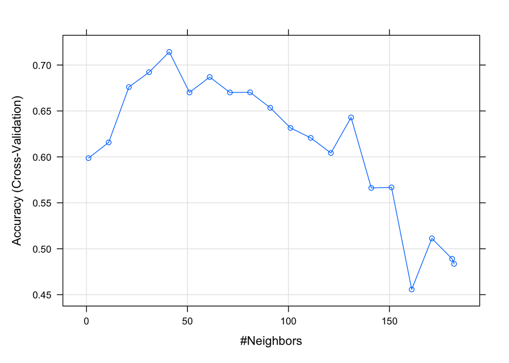

```r
plot(knn_model_3)
```

```r
knn_model_3$bestTune
```

```
##    k
## 5 41
```

```r
mean(knn_model_3$resample$Accuracy)
```

```
## [1] 0.7142643
```

```r
set.seed(253)

# We can only make predictions for cases with information on the predictor
predict_data <- na.omit(knn_model_3$trainingData)

# CLASSIFY each case in the sydney data set (using a 0.5 probability threshold)
classifications <- predict(knn_model_3, newdata = predict_data, type = "raw")

# Construct a confusion matrix
confusionMatrix(data = classifications,
  reference = as.factor(predict_data$.outcome),
  positive = "real")
```

```
## Confusion Matrix and Statistics
##
##           Reference
## Prediction fake real
##       fake   78   39
##       real   13   52
##
##                Accuracy : 0.7143
##                  95% CI : (0.6428, 0.7787)
##     No Information Rate : 0.5
##     P-Value [Acc > NIR] : 3.395e-09
##
##                   Kappa : 0.4286
##
##  Mcnemar's Test P-Value : 0.0005265
##
##             Sensitivity : 0.5714
##             Specificity : 0.8571
##          Pos Pred Value : 0.8000
##          Neg Pred Value : 0.6667
##              Prevalence : 0.5000
##          Detection Rate : 0.2857
##    Detection Prevalence : 0.3571
##       Balanced Accuracy : 0.7143
##
##        'Positive' Class : real
##
```

Since KNN algorithm suffers a lot from curse of dimentionality, we also try a new knn model with only two predictors: `TextNumOfQuotation` and `TitleLength`, which are the two most predictors selected by Forest algorithm.

#### knn_model_4

```r
#KNN
set.seed(253)

knn_model_4 <- train(
  type ~ TextNumOfQuotation + TitleLength,
  data = newsData2,
  preProcess = c("center","scale"),
  method = "knn",
  tuneGrid = data.frame(k = c(seq(1, 182, by = 10), 182)),
  trControl = trainControl(method = "cv", number = 5, selectionFunction = "best"),
  metric = "Accuracy",
  na.action = na.omit
)
```

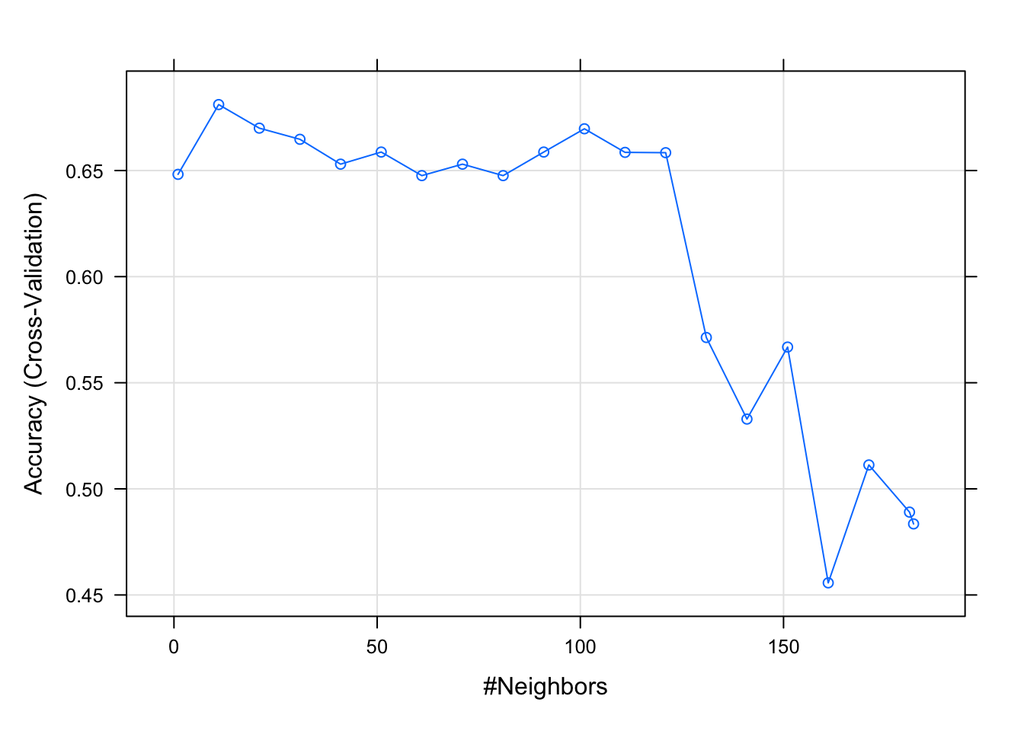

```r
plot(knn_model_4)
```

```r
knn_model_4$bestTune
```

```
##    k
## 2 11
```

```r
mean(knn_model_4$resample$Accuracy)
```

```
## [1] 0.6810811
```

```r
set.seed(253)

# We can only make predictions for cases with information on the predictor
predict_data <- na.omit(knn_model_4$trainingData)

# CLASSIFY each case in the sydney data set (using a 0.5 probability threshold)
classifications <- predict(knn_model_4, newdata = predict_data, type = "raw")

# Construct a confusion matrix
confusionMatrix(data = classifications,
  reference = as.factor(predict_data$.outcome),
  positive = "real")
```

```
## Confusion Matrix and Statistics
##
##           Reference
## Prediction fake real
##       fake   86   43
##       real    5   48
##
##                Accuracy : 0.7363
##                  95% CI : (0.666, 0.7987)
##     No Information Rate : 0.5
##     P-Value [Acc > NIR] : 6.717e-11
##
##                   Kappa : 0.4725
##
##  Mcnemar's Test P-Value : 9.270e-08
##
##             Sensitivity : 0.5275
##             Specificity : 0.9451
##          Pos Pred Value : 0.9057
##          Neg Pred Value : 0.6667
##              Prevalence : 0.5000
##          Detection Rate : 0.2637
##    Detection Prevalence : 0.2912
##       Balanced Accuracy : 0.7363
##
##        'Positive' Class : real
##
```

[output not shown]

## Part 3: Summarize

[output not shown]

Comparing the models using all variables with those without using `source`, the in-sample accuracy drasctially drops from (0.78 - 0.92) to (0.68-0.76) while the CV accuracy drops from (0.7807 - 0.8158) to (0.6972 - 0.7249), meaning that the use of `source` is **statistically cheating**.

If considering `source`, it is better to use logistic model because it has the **highest accuracy** and it is **relatively computationally efficient**, comparing to the Forest, for example. Also, it is important for us to identify fake news because the influence of **fake news might be disastrous**, and therefore we want the highest efficiency. Here, our analysis is based on the CV accuracy because values from Cross Validation prevents us from **overfitting**.

If not considering `source`, it is better to use logistic model again because of the same reasons, **the highest accuracy and relatively computationally efficient**.

We tried to have less variables in our logistic and knn models by variable selection of the Forest. However, it turns out that the CV accuracy of logistic model drops around 3% while that of knn model increases around 2% when we keep half of the variables. We also notice from the table that when we cut a lot of variables, the knn model will start to deteriorate (we just keep 2 variables in this case).

### The most important predictors

6 most important Identifed by Forest with `Source`

[output not shown]

6 most important Identifed by Forest without `Source`

| MeanDecreaseGini | Most Important predictors |
| --- | --- |
| 14.180866 | `TextNumOfQuotation` |
| 7.012116 | `TitleLength` |
| 6.969306 | `disgust` |
| 6.405099 | `surprise` |
| 6.029909 | `positive` |
| 5.833852 | `TextLength` |

Also, because we don’t want to **cheat** and fake news identification is mainly based on title and text, we believe the variables from the “non-source” Froest are the relatively more important variables.

Therefore, we visualize the relationship between the four most important variables (`TextNumOfQuotation`, `TitleLength`, `disgust`, and `surprise`) and the outcome variable y(type in this case).

To better evaluate the ranking information and understand the relationship between features, we draw a heatmap:

```r
newsData2_sub <- newsData2 %>%
  select(-type)

# Construct a correlation matrix
cor_matrix <- round(cor(newsData2_sub, use = "pairwise.complete.obs"), 2) %>%
  melt()
# Check it out
head(cor_matrix)
```

```
##                   X1            X2 value
## 1      TitleNumOfExc TitleNumOfExc  1.00
## 2      TitleNumOfQue TitleNumOfExc  0.30
## 3      TitleNumOfCap TitleNumOfExc  0.49
## 4 TextNumOfQuotation TitleNumOfExc -0.16
## 5        TitleLength TitleNumOfExc  0.18
## 6         TextLength TitleNumOfExc -0.06
```

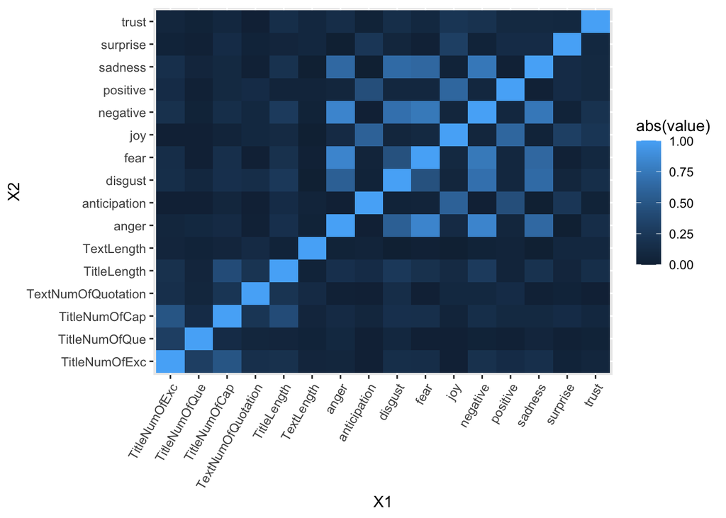

```r
# Visualize the ABSOLUTE correlation
ggplot(cor_matrix, aes(x = X1, y = X2, fill = abs(value))) +
  geom_tile() +
  theme(axis.text.x = element_text(angle = 60, hjust = 1))
```

The heatmap shows the correlation between the variables. Lighter color indicates stronger correlation between the two corresponding variable, whereas deeper color means weaker correlation.

#### TextNumOfQuotation

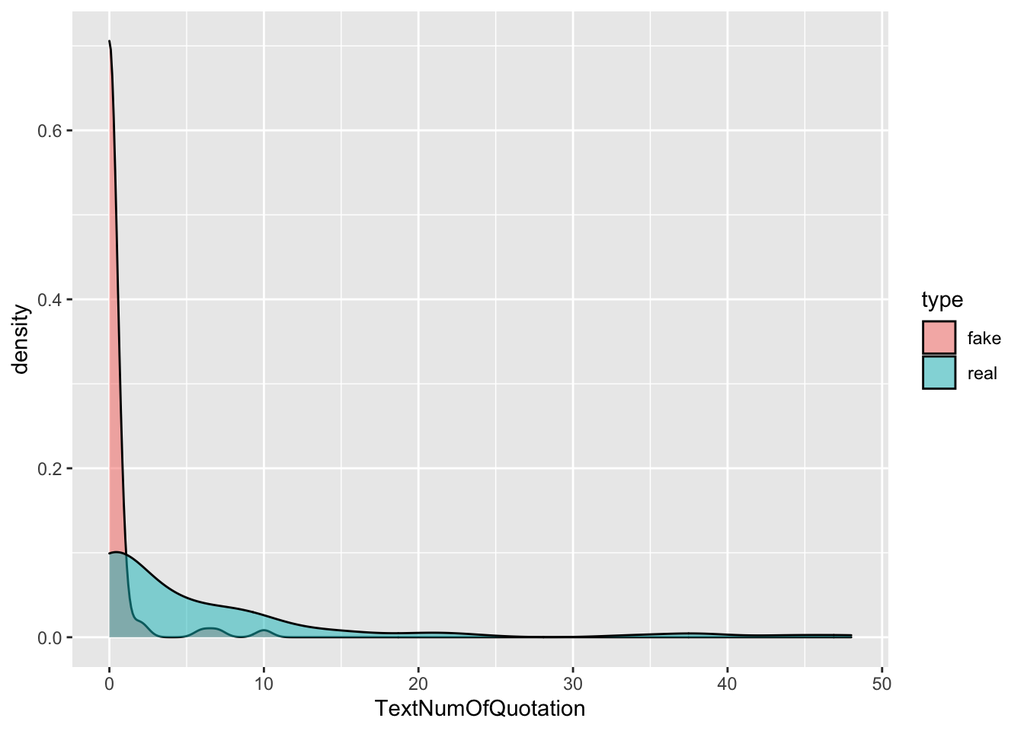

```r
ggplot(newsData, aes(x = TextNumOfQuotation,fill=type)) +
  geom_density(alpha=0.5)
```

Real news tend to have large number(0 - 50) of quotations in text, while the number of quotation marks in fake news range from (0 -10) and the most of the fake news have the number of quotations apporaching 0. The graph shows that the number of quotation mark in the text is a important predictor because there is a unique cut between real news and fake news, which is around 2 quotation marks.

#### TitleLength

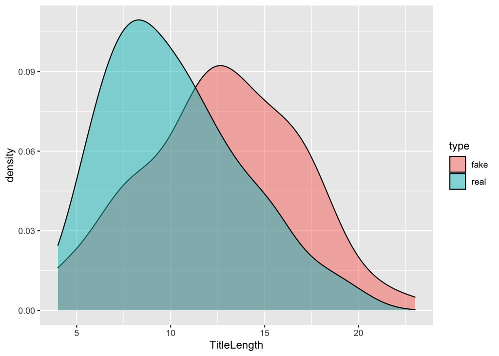

```r
ggplot(newsData, aes(x = TitleLength,fill=type)) +
  geom_density(alpha=0.5)
```

#### surprise

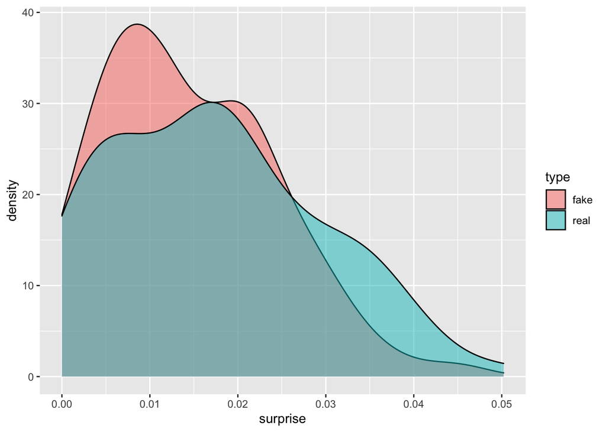

```r
ggplot(newsData, aes(x = surprise,fill=type)) +
  geom_density(alpha=0.5)
```

In general, real news appear to have a roughly symmetric distribution of (the percentage of) words associated with `suprise`, while fake news tend to have less ‘suprise’ words, or right skewed distribution. As the density of the two are largely overlaped, it appears that ‘surprise’ should be a much weaker predictor than the Forest suggested. This happens maybe `surprise` provide some unique information. From the heatmap above, we found that `surprise` does not have high correlation with any other predictors.

#### disgust

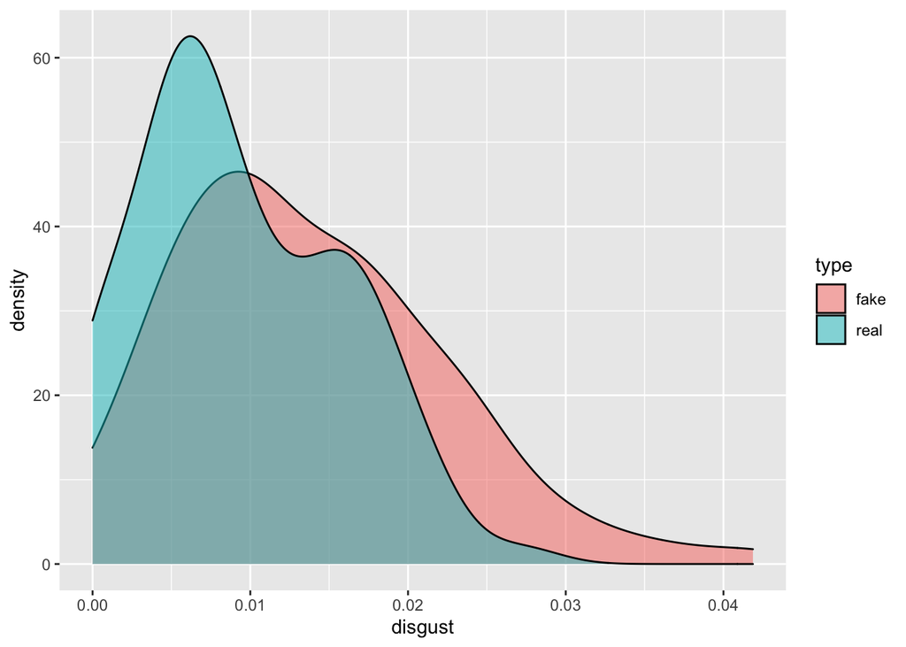

```r
ggplot(newsData, aes(x = disgust,fill=type)) +
  geom_density(alpha=0.5)
```

### The least important predictors

Because the models with `source` is **cheating**, we just extract the six least important variables from the Forest.

| MeanIncreaseGini | Most Important predictors |
| --- | --- |
| 0.3159949 | TitleNumOfQue |
| 3.6013215 | TitleNumOfExc |
| 4.2843891 | anger |
| 4.5685442 | fear |
| 4.7367663 | TitleNumOfCap |
| 4.8588023 | anticipation |

We will follow the same logic to analyze the first four important.

#### TitleNumOfQue

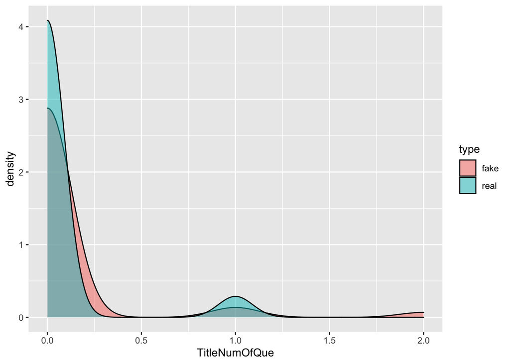

```r
ggplot(newsData, aes(x = TitleNumOfQue,fill=type)) +
  geom_density(alpha=0.5)
```

Based on the graph above, we can see that the real news and fake news are highly overlapping, and it is safe to say that this variable is not that good, which confirms with our prediction in the Forest.

#### TitleNumOfExc

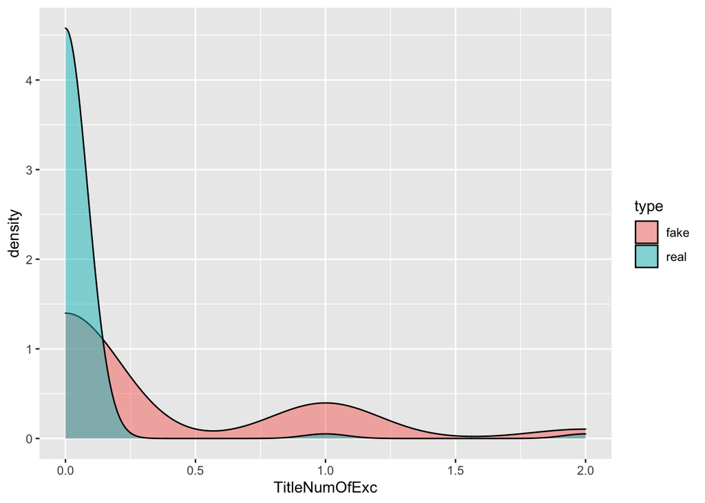

```r
ggplot(newsData, aes(x = TitleNumOfExc,fill=type)) +
  geom_density(alpha=0.5)
```

Based on the graph above, we can see that the `TitleNumOfExc` is a **very valuable predictor** because there is a good cut at around 0.25. However, the Forest classfies it as one of the least important variables. This is because `TitleNumOfExc` might be correlated with variables that have higher importance. From the heatmap, we found that `TitleNumOfExc` is correlated to both `TitleNumOfQue` `TitleNumOfCap`

#### anger

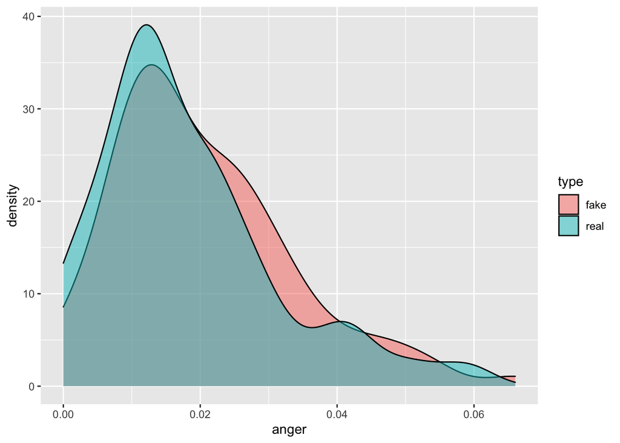

```r
ggplot(newsData, aes(x = anger,fill=type)) +
  geom_density(alpha=0.5)
```

Based on the graph, we can see that `anger` is a bad predictor because the distributions of real news and fake news are almost the same and overlpaping with each other, which confirms with the information in the Froest.

#### fear

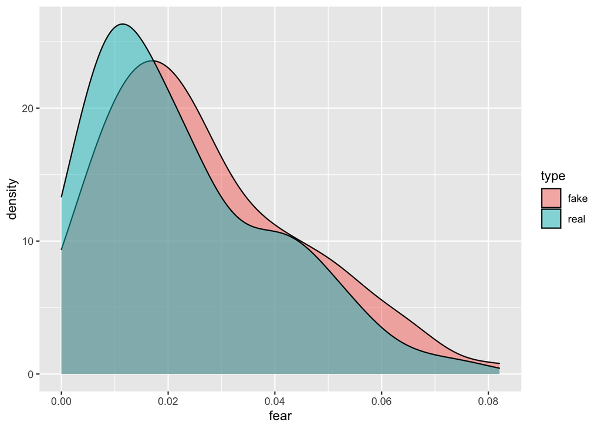

```r
ggplot(newsData, aes(x = fear,fill=type)) +
  geom_density(alpha=0.5)
```

We can get exactly the same conclusion for the variable `fear` because the overlapping area is large and the there is no natural cut that can separate between real news and fake news.

### Overall Summary

Throughout the whole analysis, here are some key take-home messages:

## Part 4: Contributions

We discussed the idea of predictors extractions and decided on the overall structure of the project. Each of us claimed a model algorithm to run and combined the results. Kaichong was mainly in charge of the data extractions, Ling and Yiming were mainly in charge of the second part analyze. The summary section was iteratively revised by each person, polished by Kaichong.

Generally speaking, all three people contribute quitely equally.

## Appendix

#### logistic_model_2

```r
# Set the seed
set.seed(253)

# Run the model
logistic_model_2 <- train(
    type ~ .,
    data = newsData2,
    method = "glm",
    family = "binomial",
    trControl = trainControl(method = "cv", number = 5),
    metric = "Accuracy",
    na.action = na.omit
)
```

```r
summary(logistic_model_2)
```

```r
set.seed(253)

# We can only make predictions for cases with information on the predictor
predict_data <- na.omit(logistic_model_2$trainingData)

# CLASSIFY each case in the sydney data set (using a 0.5 probability threshold)
classifications <- predict(logistic_model_2, newdata = predict_data, type = "raw")

# Construct a confusion matrix
confusionMatrix(data = classifications,
  reference = as.factor(predict_data$.outcome),
  positive = "real")
```

```r
logistic_model_2$results
```

#### knn_model_2

```r
#KNN
set.seed(253)

knn_model_2 <- train(
  type ~.,
  data = newsData2,
  preProcess = c("center","scale"),
  method = "knn",
  tuneGrid = data.frame(k = c(seq(1, 182, by = 10), 182)),
  trControl = trainControl(method = "cv", number = 5, selectionFunction = "best"),
  metric = "Accuracy",
  na.action = na.omit
)
```

```r
plot(knn_model_2)
```

```r
knn_model_2$bestTune
```

```r
set.seed(253)

# We can only make predictions for cases with information on the predictor
predict_data <- na.omit(knn_model_2$trainingData)

# CLASSIFY each case in the sydney data set (using a 0.5 probability threshold)
classifications <- predict(knn_model_2, newdata = predict_data, type = "raw")

# Construct a confusion matrix
confusionMatrix(data = classifications,
  reference = as.factor(predict_data$.outcome),
  positive = "real")
```

```r
mean(knn_model_2$resample$Accuracy)
```

#### tree_model_2

```r
set.seed(253)
# Construct trees
tree_model_2 <- train(
  type ~ .,
  data = newsData2,
  method = "rpart",
  tuneGrid = data.frame(cp = seq(0,0.5,length=70)),
  trControl = trainControl(method = "cv", number = 5, selectionFunction = "oneSE"),
  metric = "Accuracy",
  na.action = na.omit
)
```

```r
plot(tree_model_2)
tree_model_2$bestTune
```

```r
# Plot the tree
library(rpart.plot)
rpart.plot(tree_model_2$finalModel)

# Get metrics of variable importance
tree_model_2$finalModel$variable.importance
```

```r
set.seed(253)

# We can only make predictions for cases with information on the predictor
predict_data <- na.omit(tree_model_2$trainingData)

# CLASSIFY each case in the sydney data set (using a 0.5 probability threshold)
classifications <- predict(tree_model_2, newdata = predict_data, type = "raw")

# Construct a confusion matrix
confusionMatrix(data = classifications,
  reference = as.factor(predict_data$.outcome),
  positive = "real")
```

```r
mean(tree_model_2$resample$Accuracy)
```

#### forest_model_2

```r
set.seed(253)

forest_model_2 <- train(
  type ~ .,
  data = newsData2,
  method = "rf",
  tuneGrid = data.frame(mtry = c(2,4, 8, 16)),
  trControl = trainControl(method = "oob"),
  metric = "Accuracy",
  na.action = na.omit
)
```

```r
plot(forest_model_2)
```

```r
forest_model_2$finalModel
```

```r
(70+61)/(70+21+30+61)
```

```r
forest_model_2$results %>%
    filter(mtry == forest_model_2$bestTune$mtry)
```

```r
variable_importance <- data.frame(importance(forest_model_2$finalModel)) %>%
  mutate(predictor = rownames(.))

# Arrange predictors by importance (most to least)
variable_importance %>%
  arrange(desc(MeanDecreaseGini)) %>%
  head(6)

# Arrange predictors by importance (least to most)
variable_importance %>%
  arrange(MeanDecreaseGini) %>%
  head(6)
```